# Prediction on Medical Appointment Absence

- Introduction
- Data Wrangling
- Exploratory Data Analysis
- Conclusions

## Introduction

In this project we will investigate together data related to medical appointments in Brazil, this dataset collects information from 100k medical appointments and focused on the question of whether or not patients show up for their appointment.

## Content

The project data consists of 14 associated variables, the most important one 'show up' variable as this is our main question topic.

scholarship variable means this concept Bolsa Família is a social welfare program of the Government of Brazil, part of the Fome Zero network of federal assistance programs.

```python
# import packages

import pandas as pd #For data manipulation
import numpy as np #For scientific computing
import matplotlib.pyplot as plt #For data visualization
import seaborn as sns #For more advamced data visualization
%matplotlib inline
```

## Data Wrangling

In this section of the report, I will load in the data, check for cleanliness, and then trim and clean dataset for analysis.

### General Properties

```python
# Load data and print out a few lines. Perform operations to inspect data

df = pd.read_csv('noshowappointments-kagglev2-may-2016.csv')
df.head()
```

|  | PatientId | AppointmentID | Gender | ScheduledDay | AppointmentDay | Age | Neighbourhood | Scholarship | Hipertension | Diabetes | Alcoholism | Handcap | SMS_received | No-show |
| --- | --- | --- | --- | --- | --- | --- | --- | --- | --- | --- | --- | --- | --- | --- |
| 0 | 2.987250e+13 | 5642903 | F | 2016-04-29T18:38:08Z | 2016-04-29T00:00:00Z | 62 | JARDIM DA PENHA | 0 | 1 | 0 | 0 | 0 | 0 | No |
| 1 | 5.589978e+14 | 5642503 | M | 2016-04-29T16:08:27Z | 2016-04-29T00:00:00Z | 56 | JARDIM DA PENHA | 0 | 0 | 0 | 0 | 0 | 0 | No |
| 2 | 4.262962e+12 | 5642549 | F | 2016-04-29T16:19:04Z | 2016-04-29T00:00:00Z | 62 | MATA DA PRAIA | 0 | 0 | 0 | 0 | 0 | 0 | No |
| 3 | 8.679512e+11 | 5642828 | F | 2016-04-29T17:29:31Z | 2016-04-29T00:00:00Z | 8 | PONTAL DE CAMBURI | 0 | 0 | 0 | 0 | 0 | 0 | No |
| 4 | 8.841186e+12 | 5642494 | F | 2016-04-29T16:07:23Z | 2016-04-29T00:00:00Z | 56 | JARDIM DA PENHA | 0 | 1 | 1 | 0 | 0 | 0 | No |

```python
# work on a copied version
df.to_csv('noshowappointments-kagglev2-may-2016_copied.csv',index = False)
df = pd.read_csv('noshowappointments-kagglev2-may-2016_copied.csv')
```

```python
df.info()
```

```
<class 'pandas.core.frame.DataFrame'>
RangeIndex: 110527 entries, 0 to 110526
Data columns (total 14 columns):
PatientId         110527 non-null float64
AppointmentID     110527 non-null int64
Gender            110527 non-null object
ScheduledDay      110527 non-null object
AppointmentDay    110527 non-null object
Age               110527 non-null int64
Neighbourhood     110527 non-null object
Scholarship       110527 non-null int64
Hipertension      110527 non-null int64
Diabetes          110527 non-null int64
Alcoholism        110527 non-null int64
Handcap           110527 non-null int64
SMS_received      110527 non-null int64
No-show           110527 non-null object
dtypes: float64(1), int64(8), object(5)
memory usage: 11.8+ MB
```

### Data Cleaning

There is no missing values in any columns

As we can see the data types needs to be fixed for several columns: PatientId and AppointmentID are currently numeric where in fact they have should been string or object as they have no numeric meaning. ScheduledDay and AppointmentDay should be converted from object to date-time Other remarks: No-show should be recoded and converted into integer

```python
# convert ID variables into objects
df["PatientId"] = np.array(df["PatientId"],dtype=(str))
df["AppointmentID"] = np.array(df["AppointmentID"],dtype=(str))


# converting date varaibles from object to date
for col in ["ScheduledDay", "AppointmentDay"]:
    df[col] = pd.to_datetime(df[col])
```

```python
#changing the name of No-Show and encoding it to prevent any misconciption

#changing the name
df.rename(columns = {"No-show": "Show"}, inplace = True)

#encoding it
labels = {"No": 1, "Yes": 0}
df["Show"] = df["Show"].map(labels)

#converting it into integer
df["Show"] = np.array(df["Show"],dtype=(int))
```

```python
#check if there is any age less than zero
df.query('Age < 0')
```

|  | PatientId | AppointmentID | Gender | ScheduledDay | AppointmentDay | Age | Neighbourhood | Scholarship | Hipertension | Diabetes | Alcoholism | Handcap | SMS_received | Show |
| --- | --- | --- | --- | --- | --- | --- | --- | --- | --- | --- | --- | --- | --- | --- |
| 99832 | 465943158731293.0 | 5775010 | F | 2016-06-06 08:58:13 | 2016-06-06 | -1 | ROMÃO | 0 | 0 | 0 | 0 | 0 | 0 | 1 |

```python
# drop the wrong data
index = df.query('Age < 0').index
df.drop(index, inplace=True)
```

```python
# check for correctness
df.query('Age < 0')
```

|  | PatientId | AppointmentID | Gender | ScheduledDay | AppointmentDay | Age | Neighbourhood | Scholarship | Hipertension | Diabetes | Alcoholism | Handcap | SMS_received | Show |
| --- | --- | --- | --- | --- | --- | --- | --- | --- | --- | --- | --- | --- | --- | --- |

```python
# check for duplicated data
df.duplicated().sum()
```

```
0
```

```python
# correct some of the colmuns names to make it easy interpret
correction = {'Neighbourhood': 'Neighborhood', 'Hipertension': 'Hypertension', 'Handcap': 'Handicap'}
df.rename(columns=correction, inplace=True)
```

```python
# check that cleaning process made correctly
df.info()
```

```
<class 'pandas.core.frame.DataFrame'>
Int64Index: 110526 entries, 0 to 110526
Data columns (total 14 columns):
PatientId         110526 non-null object
AppointmentID     110526 non-null object
Gender            110526 non-null object
ScheduledDay      110526 non-null datetime64[ns]
AppointmentDay    110526 non-null datetime64[ns]
Age               110526 non-null int64
Neighborhood      110526 non-null object
Scholarship       110526 non-null int64
Hypertension      110526 non-null int64
Diabetes          110526 non-null int64
Alcoholism        110526 non-null int64
Handicap          110526 non-null int64
SMS_received      110526 non-null int64
Show              110526 non-null int64
dtypes: datetime64[ns](2), int64(8), object(4)
memory usage: 12.6+ MB
```

## Exploratory Data Analysis

```python
# # Summary Statistics
df.describe()
```

|  | Age | Scholarship | Hypertension | Diabetes | Alcoholism | Handicap | SMS_received | Show |
| --- | --- | --- | --- | --- | --- | --- | --- | --- |
| count | 110526.000000 | 110526.000000 | 110526.000000 | 110526.000000 | 110526.000000 | 110526.000000 | 110526.000000 | 110526.000000 |
| mean | 37.089219 | 0.098266 | 0.197248 | 0.071865 | 0.030400 | 0.022248 | 0.321029 | 0.798066 |
| std | 23.110026 | 0.297676 | 0.397923 | 0.258266 | 0.171686 | 0.161543 | 0.466874 | 0.401445 |
| min | 0.000000 | 0.000000 | 0.000000 | 0.000000 | 0.000000 | 0.000000 | 0.000000 | 0.000000 |
| 25% | 18.000000 | 0.000000 | 0.000000 | 0.000000 | 0.000000 | 0.000000 | 0.000000 | 1.000000 |
| 50% | 37.000000 | 0.000000 | 0.000000 | 0.000000 | 0.000000 | 0.000000 | 0.000000 | 1.000000 |
| 75% | 55.000000 | 0.000000 | 0.000000 | 0.000000 | 0.000000 | 0.000000 | 1.000000 | 1.000000 |
| max | 115.000000 | 1.000000 | 1.000000 | 1.000000 | 1.000000 | 4.000000 | 1.000000 | 1.000000 |

### Main Summary Points:

The mean age of all patients is 37

For all the patients:

- 9.8 percent have the scholarship
- 35 percent are males
- 19.7 percent have high blood pressure
- 7.2 percent are diabetic
- 3 percent drink alcohol
- 2.2 percent are handicapped
- 32.1 percent received a sms
- Show up rate is 79.8 percent

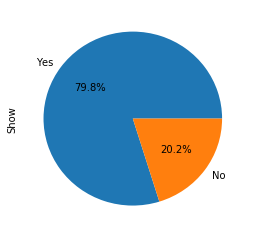

```python
# This a Pie chart which shows the absence percentage
df['Show'].value_counts().plot(kind = 'pie', figsize= (4,4),autopct='%1.1f%%',labels = ['Yes','No']);
```

Singel variable pie chart depict the patients attendance percentage

```
Gender
F    71839
M    38687
Name: PatientId, dtype: int64
```

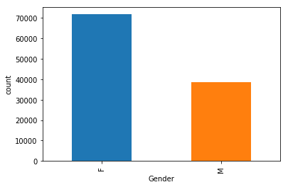

```python
df.groupby(['Gender'])['PatientId'].count().plot(kind = 'bar').set_ylabel('count')
df.groupby(['Gender'])['PatientId'].count()
```

Single variable bar plot depict the count distribution for Gender variable

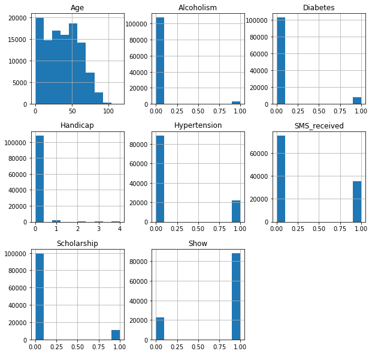

```python
# Dataset histogram
df.hist(figsize=(10,10));
```

Histograms depict the distribution of continuous features

### Research Question 1 (What our dataset tells us about attendance ratio?)

```python
# The relationship between Absence and other variables
df.groupby("Show").mean()
```

| Show | Age | Scholarship | Hypertension | Diabetes | Alcoholism | Handicap | SMS_received |
| --- | --- | --- | --- | --- | --- | --- | --- |
| 0 | 34.317667 | 0.115507 | 0.169004 | 0.064071 | 0.030333 | 0.020297 | 0.438371 |
| 1 | 37.790504 | 0.093904 | 0.204394 | 0.073838 | 0.030417 | 0.022742 | 0.291337 |

```python
# A function used to plot a gragh
def ploting_Graph (first, seconed):
    df.groupby([first])[[seconed]].mean().plot(kind = 'bar').set_ylabel('Show Ratio')
```

```python
# A function used to implement data frame
def data_frame (first,seconed):
    y = df.groupby([first])[[seconed]].mean()
    return y
```

In the below section we will visualise the above dataset:

| Gender | Show |
| --- | --- |
| F | 0.796851 |
| M | 0.800321 |

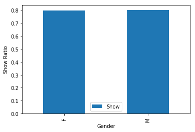

```python
# The impact of Gender feature on Absence
ploting_Graph ('Gender', 'Show')
data_frame('Gender' , 'Show')
```

Bivariate bar plot depicts the absence ratio distribution for Gender variable, the plot shows almost equal attendance ratio between male and female.

| Scholarship | Show |
| --- | --- |
| 0 | 0.801926 |
| 1 | 0.762637 |

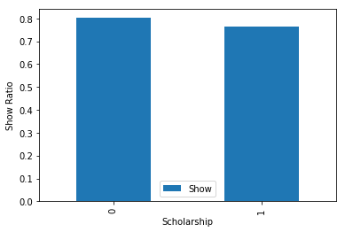

```python
# The impact of Scholarship feature on
ploting_Graph ('Scholarship', 'Show')
data_frame('Scholarship' , 'Show')
```

Bivariate bar plot depicts the absence ratio distribution for scholarship variable, the plot shows persons with no scholarship have higher attendance ratio

| Hypertension | Show |
| --- | --- |
| 0 | 0.790961 |
| 1 | 0.826980 |

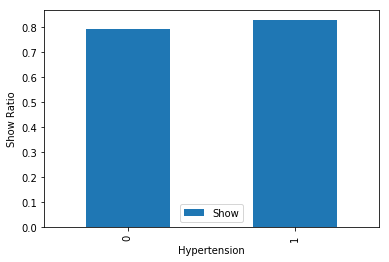

```python
# The impact of Hypertension feature on Absence
ploting_Graph ('Hypertension', 'Show')
data_frame('Hypertension' , 'Show')
```

Bivariate bar plot depicts the absence ratio distribution for Hepertension variable,the plot shows higher attendance ratio for hypertension persons

| Diabetes | Show |
| --- | --- |
| 0 | 0.796370 |
| 1 | 0.819967 |

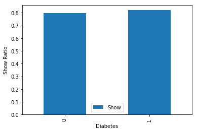

```python
# The impact of Diabetes feature on Absence
ploting_Graph ('Diabetes', 'Show')
data_frame('Diabetes' , 'Show')
```

Bivariate bar plot depicts the absence ratio distribution for Diabetes variable,the plot shows higher attendance ratio for Diabbetes persons

| Alcoholism | Show |
| --- | --- |
| 0 | 0.798052 |
| 1 | 0.798512 |

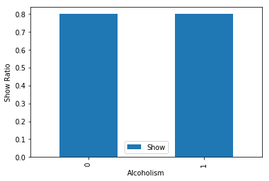

```python
# The impact of Alcoholism feature on Absence
ploting_Graph ('Alcoholism', 'Show')
data_frame('Alcoholism' , 'Show')
```

Bivariate bar plot depicts the attendance ratio distribution for Alcoholism variable,the plot shows almost equal attendance ratio for Alcoholism persons

| Handicap | Show |
| --- | --- |
| 0 | 0.797645 |
| 1 | 0.820764 |
| 2 | 0.797814 |
| 3 | 0.769231 |
| 4 | 0.666667 |

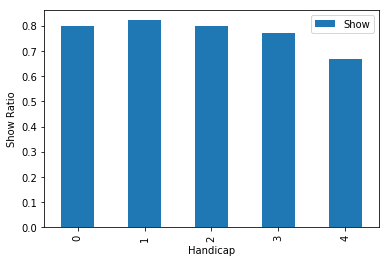

```python
# The impact of Handicap feature on Absence
ploting_Graph ('Handicap', 'Show')
data_frame('Handicap' , 'Show')
```

| SMS_received | Show |
| --- | --- |
| 0 | 0.832965 |
| 1 | 0.724255 |

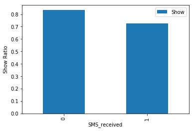

```python
# The impact of SMS_received feature on Absence
ploting_Graph ('SMS_received', 'Show')
data_frame('SMS_received' , 'Show')
```

Bivariate bar plot depicts the attendance ratio distribution for SMS received variable,the plot shows lower attendance level for persons who received SMS.

### As we can see that Scholarship has a negative impact on attendance which sounds weird, so let's investigate much more and see how it affects show up compared to hypertension people, diabetes and handicapped persons?

```python
#Scholar Hipertension Impact
pd.DataFrame(df.groupby(['Scholarship', 'Hypertension'])[['Show']].mean())
```

| Scholarship | Hypertension | Show |
| --- | --- | --- |
| 0 | 0 | 0.795092 |
|  | 1 | 0.829292 |
| 1 | 0 | 0.754261 |
|  | 1 | 0.802548 |

```python
#Scholar Diabetes Impact
pd.DataFrame(df.groupby(['Scholarship','Diabetes'])[['Show']].mean())
```

| Scholarship | Diabetes | Show |
| --- | --- | --- |
| 0 | 0 | 0.800262 |
|  | 1 | 0.822756 |
| 1 | 0 | 0.761465 |
|  | 1 | 0.783831 |

```python
#Scholar Handicap Impact
pd.DataFrame(df.groupby(['Scholarship','Handicap'])[['Show']].mean())
```

| Scholarship | Handicap | Show |
| --- | --- | --- |
| 0 | 0 | 0.801623 |
|  | 1 | 0.819872 |
|  | 2 | 0.781818 |
|  | 3 | 0.769231 |
|  | 4 | 0.666667 |
| 1 | 0 | 0.761303 |
|  | 1 | 0.831250 |
|  | 2 | 0.944444 |

### Research Question 2 ( Is age the reason why patient does not show up ? )

#### First of all lets explore data related to age in our data set

```python
df['Age'].describe()
```

```
count    110526.000000
mean         37.089219
std          23.110026
min           0.000000
25%          18.000000
50%          37.000000
75%          55.000000
max         115.000000
Name: Age, dtype: float64
```

#### lest us plot a simple Boxplot allow us to depict the distribution of age to absence relationship

| Show | mean | std |
| --- | --- | --- |
| 0 | 34.317667 | 21.965941 |
| 1 | 37.790504 | 23.338645 |

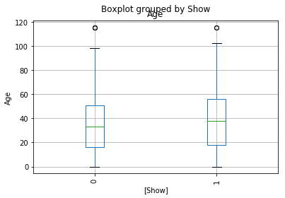

```python
df.boxplot(column = ['Age'], by = ['Show'], rot = 90,)
plt.ylabel("Age")
pd.DataFrame(df.groupby(['Show'])['Age'].describe().loc[:, ['mean','std']])
```

#### lest's plot a histogram for Age of Patients Absent and Present distribution at the Appointment

```python
df_absence = df.query('Show == 0')
df_presence = df.query('Show == 1')
```

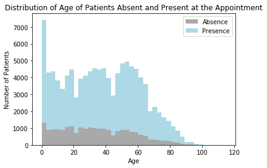

```python
#plotting histogram of patients by Absence.

fig, ax = plt.subplots()
plt.hist([df_absence['Age'], df_presence['Age']], bins=40, label=['Absence', 'Presence'], color = ['darkgrey', 'lightblue'], stacked=True)
plt.title('Distribution of Age of Patients Absent and Present at the Appointment')
plt.ylabel('Number of Patients')
plt.xlabel('Age')
plt.legend();
```

#### Lets plot a ratio between age and absence only

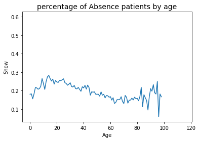

```python
#plotting percentage of patients Absence up by age

Age_ratio = df[df.Show == 0].groupby(['Age']).size()/df.groupby(['Age']).size()
Age_ratio.plot()
plt.title('percentage of Absence patients by age', size='14')
plt.ylabel('Show')
plt.show()
```

### Answer question 2:

The patients in the youth group (15~24 years old) showed highest absence ratio, while those in the seniors group (65 years old and over) showed lowest absence ratio.

### Research Question 3 (what does neigbourhood to do with not showing up ? )

First, let us see how many neighourhood we have in our dataset?

```python
df['Neighborhood'].nunique()
```

```
81
```

How many samples the data include?

```python
df['Neighborhood'].value_counts().head(10)
```

```
JARDIM CAMBURI       7717
MARIA ORTIZ          5805
RESISTÊNCIA          4431
JARDIM DA PENHA      3877
ITARARÉ              3514
CENTRO               3334
TABUAZEIRO           3132
SANTA MARTHA         3131
JESUS DE NAZARETH    2853
BONFIM               2773
Name: Neighborhood, dtype: int64
```

lets represent our data in a bar chart to show us more details

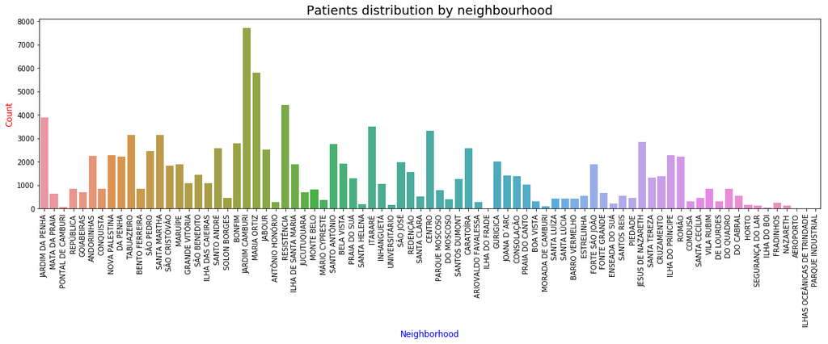

```python
#plotting number of patients from each neighbourhood
plt.figure(figsize=(20,5))
plt.title('Patients distribution by neighbourhood',fontsize = 18)
sns.countplot(x=df.Neighborhood, data=df);
plt.xticks(rotation='90')
plt.xlabel('Neighborhood', fontsize = 12, color = 'blue')
plt.ylabel('Count', fontsize = 12, color = 'red')
plt.show()
```

#### Lets plot a gragh showing up ratio between absence and neighbourhood

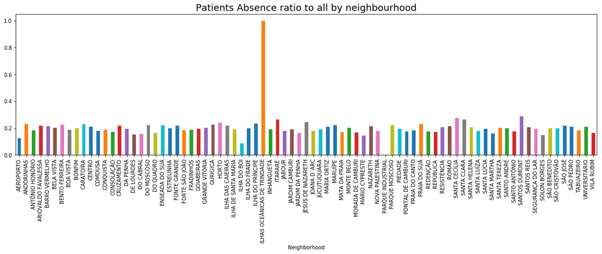

```python
#Plotting ratio between showing up and all patients for every neighbourhood

ratio = df[df.Show == 0].groupby('Neighborhood').size()/df.groupby('Neighborhood').size()
plt.figure(figsize=(20,5))
plt.title('Patients Absence ratio to all by neighbourhood', fontsize = 18)
ratio.plot(kind='bar');
```

### Answer question 3:

Do you think that the number of samples is a good representative of the population for those two neighbourhood? Let us check!!

```python
#printing number of patients in the 2 neigbourhood with irregular NoShow ratio.

Neighborhood_counts = np.array([df.Neighborhood.value_counts()['ILHAS OCEÂNICAS DE TRINDADE'],
df.Neighborhood.value_counts()['PARQUE INDUSTRIAL']])
Neighborhood_counts
```

```
array([2, 1])
```

As we can see there are no much patients data in those 2 neighboorhood to have an insight,I think that missing values might influence the results of the analysis so we can ignore them.

## Conclusions

Impact of variables to attendence ratio:

According to our dataset we found that :

[output not shown]

Impact of Age :

```
* The mean age of all patients is 37
* The patients in the youth group (15~24 years old) showed highest absence ratio, while those in the seniors group (65           years old and over) showed lowest absence ratio.
* This means people with older age is highly stick with medical appointment
```

Impact of neighourhood:

[output not shown]

Limitations :

```
* The dataset collects information for 100k medical appointments in Brazil, according to the last statistic in 2019               Brazil's population is 211 million, which means that we won't be able to provide accurate analytical information.
* There is a variance in the gathered data samples across the neighborhood, we found that there is a neighborhood that           contains more than 7000 samples and the others only have one sample.
* while wrangling our dataset found that there was an age less than zero which doesn't make sense, which leads us to             drop such kind of dataset
```

Here is a Refrence list for the websites used in this project:

- https://classroom.udacity.com/
- https://nfpdiscussions.udacity.com/
- https://www.python.org/
- https://pandas.pydata.org/
- https://numpy.org/doc/stable/reference/arrays.html
- https://stackoverflow.com/
- https://matplotlib.org/
- https://seaborn.pydata.org/
- https://www.kaggle.com/joniarroba/noshowappointments
- https://realpython.com/python-csv/
- https://www.geeksforgeeks.org/
- https://www.google.com

```python
from subprocess import call
call(['python', '-m', 'nbconvert', 'Investigate_a_Dataset.ipynb'])
```

```
255
```